# KUSHAGRA AGARWAL 2018113012

# Coin toss

If a coin has a probability of $p$ for showing heads and $q=1-p$ for showing heads, then the probability of seeing $M$ heads when coin is tossed $n>M$ times is given by: $$ P(M;n) = \frac{n!}{M!(n-M)!} p^M q^{n-M} $$

If the average the number of heads is denoted $M_n\equiv M/n$, then clearly $0\le M_n \le 1$ and we expect that $M_{n\rightarrow \infty} = p$. For $M_n$ being in the range $(x,y)$, we have: $$ Prob(x<M_n<y) = \sum_{r \in \mathcal Z~\wedge~x<\frac{r}{n}<y} P(r;n) $$

```python
import numpy as np
import random
import numpy.random
import scipy
import scipy.special
import math
import matplotlib.pyplot as plt
import scipy.optimize
```

## Task-1:

1. Plot $\log P(M_n=x)$ vs $x$ for various $n$. Note that $\int_{0}^{1} dx~P(M_n=x) = 1$.
2. Show that $P(M_n=x)$ near $x=\frac{1}{2}$ is Gaussian. Do this by fitting a gaussian to Mn=x

```python
def calcprob(M,n,p,q):
    '''This function takes in as parameter 4 inputs:
    M-the number of heads
    n-total number of coin tosses
    p-probability of heads
    q-probability of tails

    The function returns a single float value
    The value is the probability of M heads in n tosses'''
    P=scipy.special.comb(n,M)*(p**M)*(q**(n-M))
    #this scipy module returns n(c)M
    return P

print(calcprob(10,40,0.5,0.5))
print(calcprob(1,1,0.5,0.5))
```

```
0.0007709427591180429
0.5
```

```python
def plotprob(n,p,q):
    '''This function takes in as input 3 values:
    n-total number of coin tosses
    p-probability of a toss giving heads
    q-probability of a toss giving tails

    The function returns a plot of probability of number of heads from 0 to n for each n'''
    step=1/n
    x=np.arange(0,1,step)
    #creates an array of all x in the range 0,1 with step being 1/n provided
    z=[0.0]*n
    count=0
    for i in x:
        z[count]=calcprob((int)(i*n),n,p,q)*n
        #calculating probability for each i in x and storing it in array z
        #we typecasted i*n to int as i was a real number and needed to be converted to int
        #as factorial works only on integer values
        count+=1
    plt.xlabel('Average number of Heads')
    plt.plot(x,z,label="n="+str(n))
    plt.legend()
```

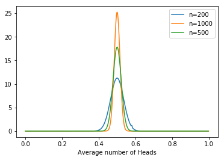

```python
plotprob(200,0.5,0.5)
plotprob(1000,0.5,0.5)
plotprob(500,0.5,0.5)
```

```python
def plotlogprob(n,p,q):
    '''This function takes in as input 3 values:
    n-total number of coin tosses
    p-probability of a toss giving heads
    q-probability of a toss giving tails

    The function returns a plot of log of probability of number of heads from 0 to n for each n'''
    step=1/n
    x=np.arange(0,1,step)
    z=[0.0]*n
    count=0
    for i in x:
        z[count]=math.log(calcprob((int)(i*n),n,p,q)*n)
        #same as plotprob but now we just compute the math.log of the value before storing
        count+=1
    plt.xlabel('Average number of heads m/n')
    plt.ylabel('Log of Probability of getting m heads')
    plt.title("log(P) vs M_n")
    plt.plot(x,z,label="n="+str(n))
    plt.legend()
```

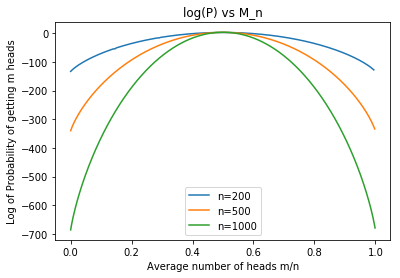

```python
plotlogprob(200,0.5,0.5)
plotlogprob(500,0.5,0.5)
plotlogprob(1000,0.5,0.5)
```

```python
def gaussianvalue(x, a, c, sig):
    '''This function returns the value of gaussian with given parameters
    Input parameters x,a,c,sigma

    Output- Value of Gaussian function with the following parameters
    '''
    c=(((x-c)/sig)**2)
    d=np.exp((-0.5)*c)

    return a * d

import scipy.optimize

def curvefitting(n):
    '''This function would plot the Gaussian and would also plot the probability graph for 0.5. After this using curve_fit module of scipy we would be showing that indeed the two graphs are similar.

    Input- The function takes as input the timestep or n number of partitions of the line space 0-1
    Output- A graph of the Probability Function, a graph of the Gaussian Function, and a graph that would have both the Gaussian and the probability graph fitted and thus showing similarity between the two.
    '''


    x=np.linspace(0, 1, n)
    y1=[0.0]*n

    for i in x:
        f=(int)(99*i)
        y1[f]=calcprob((int)(i*n),n,0.5,0.5)
    #y1 has the data from the probability function

    plt.xlabel('Average number of heads m/n')
    plt.ylabel('Probability of getting m heads')
    answer=scipy.optimize.curve_fit(gaussianvalue, x ,y1)[0]
    #curve fitting the two graphs using scipy module
    y2=gaussianvalue(x, *answer)
    plt.plot(x, y1, label='Data from Probability Function')
    plt.title("Data from Probability Function")
    plt.legend()
    plt.show()
    plt.plot(x, y2, label='Gaussian Function')
    plt.title("Gaussian Function")
    plt.legend()
    plt.show()
    plt.xlabel('Average number of heads m/n')
    plt.ylabel('Probability of getting m heads')
    plt.plot(x, y2, label='Gaussian Function')
    plt.plot(x, y1, 'ro',label='Data from Probability Function')
    plt.title("Original data fitted to Gaussian")
    plt.legend()
    print('Parameters for gaussian:')
    print('a:',answer[0])
    print('c:',answer[1])
    print('sigma:',answer[2])
```

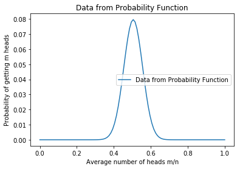

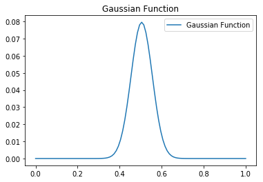

```
Parameters for gaussian:
a: 0.07963886887618099
c: 0.5050505050505149
sigma: -0.050631576038895516
```

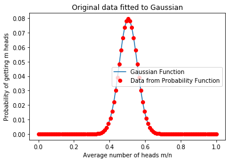

```python
curvefitting(100)
```

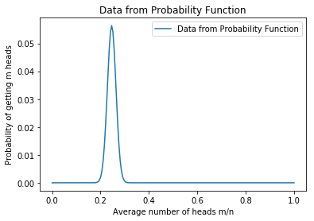

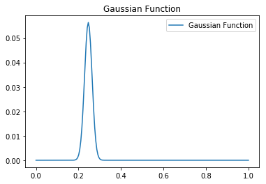

```
Parameters for gaussian:
a: 0.05636606838584508
c: 0.24623115577889473
sigma: -0.017788733295044563
```

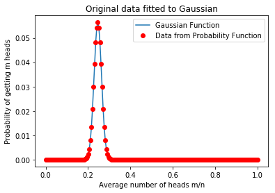

```python
curvefitting(200)
```

The graph fits the gaussian perfectly

## Task-2: Assume a fair coin from now on i.e. $p=q=\frac{1}{2}$

Plot $\log P(M_n > x)$ as a function of $n\in[1,250]$ for $x=0.6,~0.7,~0.8,~0.9$

```python
def calcPgx(a,n):
    '''This function returns value of P(M_n > x) for a certain a and n number of coin tosses.
    For a certain value of x we get a certain value of P(M_n>x) by using the summation property given above

    Input type-

    Two parameters are to be taken a and n

    a represents the start value
    n represents the number of coin tosses

    Output type-

    a single value that gives P(M_n>x) for the input
    '''
    result=0
    for i in range(a,n):
        result=result+calcprob(a,n,0.5,0.5) #this sums up the probabilities from a henceforth
    return result
```

```python
def plotTask2(x):
    '''A function that plots log(P(M_n > x)) for the input value x

    Input type-

    One parameter to be input x

    Output type-

    A plot that returns the log of the value as a function x
    '''
    A=[0.0]*249
    for i in range(1,250):
        A[i-1]=calcPgx(int(x*i),i)
    #converting the values of A to the logarithm of the values
    #for i in range(1,250):
    #   A[i-1]=math.log(A[i-1])
    plt.semilogy(range(1,250),A,label='x='+str(x))
    #plt.plot(A,range(1,250))
    plt.legend()
    plt.title("log(P(M_n > x)) vs x")
    plt.ylabel('log(P(M_n > x))')
    plt.xlabel('N')
```

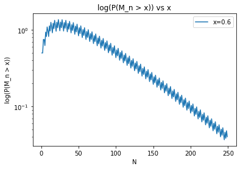

```python
plotTask2(0.6)
```

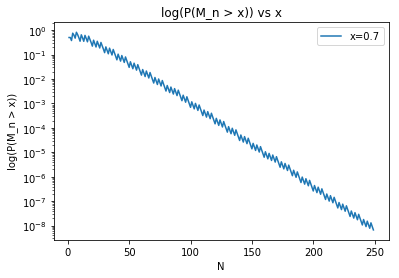

```python
plotTask2(0.7)
```

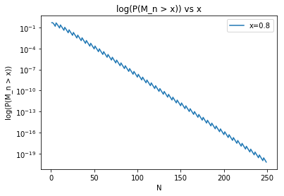

```python
plotTask2(0.8)
```

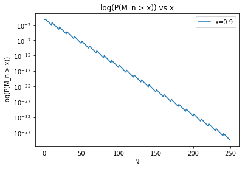

```python
plotTask2(0.9)
```

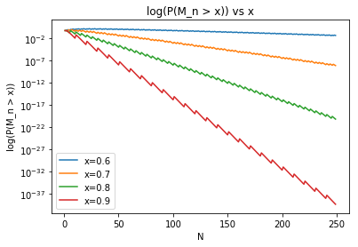

```python
plotTask2(0.6)
plotTask2(0.7)
plotTask2(0.8)
plotTask2(0.9)
```

## Task-3:

Note that for large $N$, the above plots are linear. Fit the above plots (of $\log Prob(M_n >x)$ vs $n$) to straight lines for large $n$ and get the slope, which we will call $I(x)$. Now plot $I(x)$ vs $x$.

```python
def plotfitting(x):
    '''This function plots a curve fitting graph for I(x) and the plot from Task2

    Input-

    One parameter x

    Ouput-

    A curve fitting graph of the I(x) versus the plot from Task2
    '''
    y=[0.0]*250
    for i in range(1,250):
        a=calcPgx(int(x*i),i)
        b=math.log(a)
        y[i-1]=b
    #print(y)
    answer=scipy.optimize.curve_fit(gaussianvalue, range(0,250) ,y)[0]
    #curve fitting done
    ans=answer[0]
    A=[0.0]*250;
    for i in range(1,250):
        A[i-1]=i*ans
    plt.plot(range(0,250),A,'ro',label="fit x="+str(x))
    plotTask2(x)
```

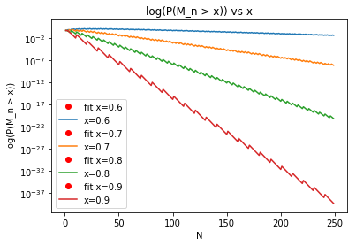

```python
plotfitting(0.6)
plotfitting(0.7)
plotfitting(0.8)
plotfitting(0.9)
```

```python
def plotTask3():
    '''This function plots I(x) versus x for all x from 0 to 1

    Input- None
    Output- The graph I(x) versus x
    '''

    A=np.arange(0.01,1,0.01)
    B=[]


    for j in A:
        y=[0.0]*250
        for i in range(1,250):
            a=calcPgx(int(j*i),i)
            b=math.log(a)
            y[i-1]=b
        answer=scipy.optimize.curve_fit(gaussianvalue, range(0,250) ,y)[0]
        B.append(answer[0])#the same value as used in previous function has been appended to the list


    plt.plot(A,B) #A represents X and B is I(x)
    plt.ylabel("I(X)")
    plt.xlabel("X")
    plt.title("I(x) vs x")
```

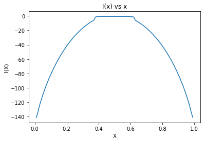

```python
plotTask3()
```

## Task-4: Random walk

Let $c(t)$ be the result of coin toss, tossed at time $t$. Then Random Walk is given by $$ x(t+1) = x(t) + \delta_{c(t),H} - \delta_{c(t),T} $$ with $x(0)=0$.

Plot a one realisation of $x(t)$ for $t\in[0,100]$

```python
def randomwalkgenerate():
    '''This function generates a random walk from 0 to whatever value it can get to using the formula
    X(t)=X(t-1)+(-1/1)
    To get the random nature of the plot i used the random.randint function for the range 0-9
    if the value is >4 it returns 1 or else -1

    Input type- None

    Output- A graph starting from 0 and depicting a random walk according to tne aforesaid parameters
    '''
    walk=[0.0]*100
    #b=random.randint(0,9)
    #if(b>4):
    #   walk[0]=1
    #else:
    #    walk[0]=-1
    walk[0]=0
    for i in range(1,100):
        b=random.randint(0,9)#generates a random integer between 0 and 9
        if(b>4):#if b=0,1,2,3,4 that is 50% probable
            c=1
        else: #if b=5,6,7,8,9 the rest 50% probability
            c=-1
        walk[i]=walk[i-1]+c #new position = old position + the value +1 or -1
    plt.plot(range(0,100),walk)
    plt.title("Random Walk")
    plt.xlabel('T')
    plt.ylabel('X(T)')
```

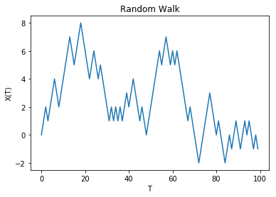

```python
randomwalkgenerate()
```

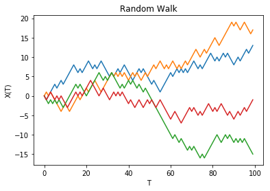

```python
randomwalkgenerate()
randomwalkgenerate()
randomwalkgenerate()
randomwalkgenerate()
```

## Task-5: Moments of distribution of $x(t)$

1. What would be $\langle x(t) \rangle$?
2. What would be $\langle x^2(t) \rangle$? Why?
3. Compute them by genrating a sample of random walks. Comment on the 'error' of the calculation

```python
def computavgx(a):
    '''This function returns the plot of <x(t)> computed for each t from 1 to 100

    Input type

    One parameter a which defines the number of random walks to be considered while finding the average

    Output

    A graph of <x(t)> versus t for a certain value of a'''
    walk=[0.0]*100
    value=[0.0]*100
    for j in range(a):
        walk[0]=0
        for i in range(1,100):
            b=random.randint(0,9)
            if(b>4):
                c=1
            else:
                c=-1
            walk[i]=walk[i-1]+c
        #the walk has been created
        for i in range(0,100):
            value[i]=value[i]+walk[i] #adding walk values at all the T's
    answer=[0.0]*100
    for i in range(0,100):
        answer[i]=value[i]/a #we take the average of all the values
    plt.plot(range(0,100),answer,label="a="+str(a))
    plt.xlabel("T")
    plt.ylabel("Average of X(T)")
    plt.title("<x(t)> vs t")
    plt.legend()
```

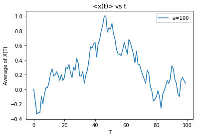

```python
computavgx(100)
```

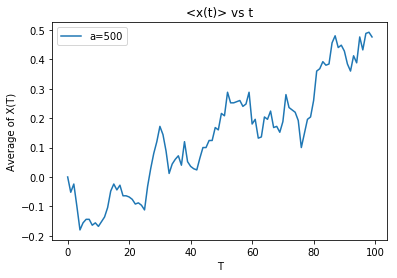

```python
computavgx(500)
```

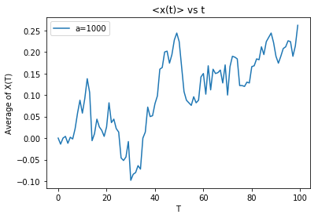

```python
computavgx(1000)
```

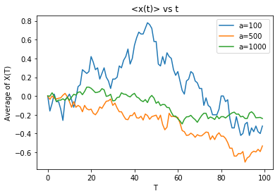

```python
computavgx(100)
computavgx(500)
computavgx(1000)
```

Interpretation of the Result:

As we increase the number of iterations ideally the average value should come closer to zero . Following this principle, the graph of 1000 should be closer to the line y=0 than the graphs for x=500 and x=100 respectively

```python
def computavgxsq(a):
    '''This function returns the plot of <x(t)^2> computed for each t from 1 to 100

    Input type

    One parameter a which defines the number of random walks to be considered while finding the average

    Output

    A graph of <x(t)> versus t for a certain value of a'''
    walk=[0.0]*100
    value=[0.0]*100
    for j in range(a):
        walk[0]=0
        for i in range(1,100):
            b=random.randint(0,9)
            if(b>4):
                c=1
            else:
                c=-1
            walk[i]=walk[i-1]+c
        #the walk has been created
        for i in range(0,100):
            value[i]=value[i]+(walk[i]*walk[i]) #adding walk values squared at all the T's
    answer=[0.0]*100
    for i in range(0,100):
        answer[i]=value[i]/a #taking average of all the values
    plt.plot(range(0,100),answer,label="a="+str(a))
    plt.xlabel("T")
    plt.ylabel("Average of X(T)^2")
    plt.title("<x(t)^2> vs t")
    plt.legend()
```

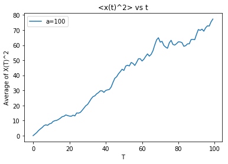

```python
computavgxsq(100)
```

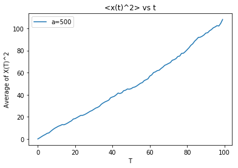

```python
computavgxsq(500)
```

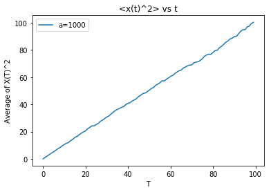

```python
computavgxsq(1000)
```

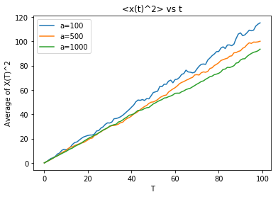

```python
computavgxsq(100)
computavgxsq(500)
computavgxsq(1000)
```

Interpretation of the Result:

The graph again shows the random walks averaged but this time instead of taking the average of the values we instead take the average of the square of the values. As we have squared the values there is no negative part and the deviation from zero is positive. Even in this graph the structure holds wherein 1000 should deviate lesser as compared to 500 and 100 respectively